## Solutions to Assignment 9

#### Due Friday, November 6, 11:59 PM CT

### 1

> Read in the `chimpanzee.csv` data file. Consider only those trials with a partner. Make an assumption that there is a universal $p_{\text{partner}}$ during which any chimpanzee would make a prosocial choice in a single trial under the experimental conditions we have been examining. Assume that all trials are independent. Under these assumptions, write down a statistical model for $X_1$, the total number of prosocial choices made with a partner present in this experiment. Test the hypothesis that $p_{\text{partner}} = 0.5$ versus the two-sided alternative that it does not. Report a p-value. Create a graph that shows the sampling distribution of $X_1$ under the null hypothesis and indicates (with different colors and/or lines) how the p-value relates to the graph. Interpret the results of the hypothesis test in context.

### Solution

```r
chimps_orig = read_csv("../../data/chimpanzee.csv")

chimps = chimps_orig %>%
  mutate(group = case_when(
    partner == "none" ~ "no partner",
    TRUE ~ "partner")) %>%
  group_by(group) %>%
  summarize(prosocial = sum(prosocial),
            selfish = sum(selfish),
            n = prosocial + selfish,
            p = prosocial / n)

chimps
```

```
## # A tibble: 2 x 5
##   group      prosocial selfish     n     p
##   <chr>          <dbl>   <dbl> <dbl> <dbl>
## 1 no partner        83      97   180 0.461
## 2 partner          359     251   610 0.589
```

> Under these assumptions, write down a statistical model for $X_1$, the total number of prosocial choices made with a partner present in this experiment.

$$X_1 \sim \text{Binomial}(610,0.5)$$

> Test the hypothesis that $p_{\text{partner}} = 0.5$ versus the two-sided alternative that it does not.

$H_0:\ p_{\text{partner}} = 0.5$  
$H_a:\ p_{\text{partner}} \neq 0.5$

> Report a p-value.

```r
## Find the values of x where the probability of the data
##   is the same or smaller than the observed value of 359
n = 610
x = 359
p0 = 0.5
tol = 1e-8

## E(X) = 305
## 359 - 305 = 54
## 305 - 54 = 251
## Should be x <= 251 and x >= 359
all_x = 0:n
extreme_x = all_x[dbinom(all_x, n, p0) < dbinom(x, n, p0) + tol]
pvalue = sum( dbinom(extreme_x, n, p0))
pvalue
```

```
## [1] 1.405895e-05
```

```r
## Alternatively
pvalue2 = pbinom(251,n,p0) + (1 - pbinom(358,n,p0))
pvalue2
```

```
## [1] 1.405895e-05
```

The p-value is 0.000014.

> Create a graph that shows the sampling distribution of $X_1$ under the null hypothesis and indicates (with different colors and/or lines) how the p-value relates to the graph.

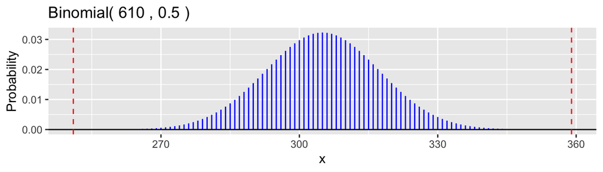

```r
gbinom(n,p0, scale = TRUE) +
  geom_vline(xintercept = x, color = "red", linetype = "dashed") +
  geom_vline(xintercept = 251, color = "red", linetype = "dashed")
```

> Interpret the results of the hypothesis test in context.
- There is strong evidence that chimpanzees make the prosocial with a partner present choice more than half the time in the experimental settings ($p = 0.000014$, two-sided binomial test).

Note that with a two-sided test where we could potentially conclude that that $p$ is greater or smaller than $p=0.5$, the p-value includes probability in both tails of the null sampling distribution but the conclusion is directional because the observed test statistic is in the right tail.

### 2

> Repeat the previous problem, but use the data for all trials without a partner for an assumed universal parameter $p_{\text{no partner}}$, using a statistical model for $X_2$, the total number of prosocial choices made without a partner present in this experiment.

### Solution

> Under these assumptions, write down a statistical model for $X_2$, the total number of prosocial choices made without a partner present in this experiment.

$$X_2 \sim \text{Binomial}(180,0.5)$$

> Test the hypothesis that $p_{\text{no partner}} = 0.5$ versus the two-sided alternative that it does not.

$H_0:\ p_{\text{no partner}} = 0.5$  
$H_a:\ p_{\text{no partner}} \neq 0.5$

> Report a p-value.

```r
## Find the values of x where the probability of the data
##   is the same or smaller than the observed value of 359
n = 180
x = 83
p0 = 0.5
tol = 1e-8

## E(X) = 90
## Should be x <= 83 and x >= 97
all_x = 0:n
extreme_x = all_x[dbinom(all_x, n, p0) < dbinom(x, n, p0) + tol]
pvalue = sum( dbinom(extreme_x, n, p0))
pvalue
```

```
## [1] 0.3325791
```

```r
## Alternatively
pvalue2 = pbinom(83,n,p0) + (1 - pbinom(96,n,p0))
pvalue2
```

```
## [1] 0.3325791
```

The p-value is 0.33.

> Create a graph that shows the sampling distribution of $X_2$ under the null hypothesis and indicates (with different colors and/or lines) how the p-value relates to the graph.

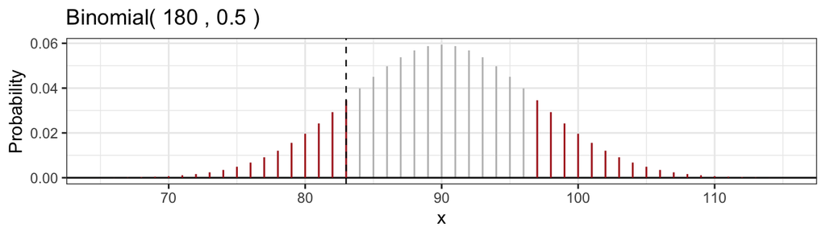

```r
## a = 65 and b = 115 from trial and error to find a nice interval
gbinom(n,p0, a = 65, b = 115, color = "gray") +
  geom_binom_density(n, p0, a = 97, b = 115, color = "firebrick") +
  geom_binom_density(n, p0, a = 65, b = 83, color = "firebrick") +
  geom_vline(xintercept = x, linetype = "dashed", size = 0.4, color = "black") +
  theme_bw()
```

> Interpret the results of the hypothesis test in context.
- The data is consistent with chimpanzees making the prosocial choice half the time with no partner present in the experimental settings ($p = 0.33$, two-sided binomial test).

### 3

> Hypothesis tests may also be used to compare population proportions. Here, we wish to test the null hypothesis that $p_{\text{partner}} = p_{\text{no partner}}$ versus the alternative that they are different. Notice that this hypothesis statement differs from the previous two in that there is no specific value for the proportions to be equal to if the null hypothesis is true. This problem will lead you through a randomization approach to test the hypothesis.

##### (a)

Let $p$ be the unknown shared probability of making the prosocial choice in a single trial if the null hypothesis is true. Write down statistical models for $X_1$ and $X_2$ defined in the previous problems under this hypothesis.

##### Solution

$$X_1 \sim \text{Binomial}(610,p)$$
$$X_2 \sim \text{Binomial}(180,p)$$

##### (b)

Under the null hypothesis, what is a statistical model for $X = X_1 + X_2$? Use the combined data from the experiment with all trials with and without a partner to find the maximum likelihood estimate for $p$ assuming the null hypothesis is true.

##### Solution

$$X \sim \text{Binomial}(790,p)$$

```r
chimps2 = chimps %>%
  summarize(prosocial = sum(prosocial),
            selfish = sum(selfish),
            n = sum(n),
            phat = prosocial/n)

chimps2
```

```
## # A tibble: 1 x 4
##   prosocial selfish     n  phat
##       <dbl>   <dbl> <dbl> <dbl>
## 1       442     348   790 0.559
```

- The maximum likelihood estimate is $\hat{p} = 0.5595$

##### (c)

Use simulation to conduct the experiment $B = 10,000$ times using the value for $p$ estimated in the previous problem. This results in $B$ simulated values $X^*_1$ and $X^*_2$ from the assumed statistical model. For each corresponding replicate of the simulation, calculate a test statistic which is the difference in sample proportions. This collection of simulated proportion differences is a simulation-based estimate of the sampling distribution of the test statistic. Find the mean and standard deviation of this distribution.

##### Solution

```r
set.seed(20201031)
B = 10000
p0 = chimps2$phat
n1 = 610
n2 = 180

dat = tibble(
  x1 = rbinom(B, n1, p0),
  x2 = rbinom(B, n2, p0),
  phat1 = x1/n1,
  phat2 = x2/n2,
  stat = phat1 - phat2
)

dat_sum = dat %>%
  summarize(
    mean = mean(stat),
    sd = sd(stat))

dat_sum
```

```
## # A tibble: 1 x 2
##         mean     sd
##        <dbl>  <dbl>
## 1 -0.0000886 0.0423
```

##### (d)

What should the value of the the mean of the sampling distribution approach if we let $B$ approach infinity? What special two-word name is given to the standard deviation of this sampling distribution?

##### Solution

- The mean should approach 0. Under the null hypothesis, both sample proportions have the same expected value.
- It is called the **standard error**.

##### (e)

Display the distribution of the simulated sampling distribution. Add to this graph a vertical line which is the realized test statistic from the actual data.

##### Solution

```r
test_stat = chimps %>% filter(group == "partner") %>% pull(p) -
  chimps %>% filter(group == "no partner") %>% pull(p)

test_stat
```

```
## [1] 0.1274135
```

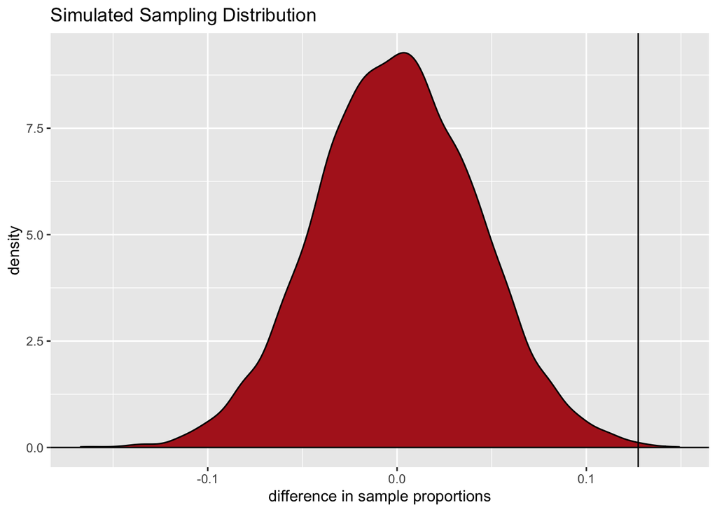

```r
ggplot(dat, aes(x=stat)) +
  geom_density(fill = "firebrick") +
  geom_hline(yintercept=0) +
  geom_vline(xintercept = test_stat) +
  xlab("difference in sample proportions") +
  ggtitle("Simulated Sampling Distribution")
```

##### (f)

Calculate the p-value for this hypothesis test. You may either directly report the proportion of extreme simulated proportion differences or make an approximation based on the shape of the sampling distribution to compute an area under an appropriate density curve.

```r
## Direct calculation
pval_1 = dat %>%
  summarize(pval = mean(abs(stat) >= test_stat) ) %>%
  pull(pval)

pval_1
```

```
## [1] 0.0028
```

```r
## Normal Approximation
pval_2 = 2 * (1 - pnorm(test_stat, 0, dat_sum$sd))

pval_2
```

```
## [1] 0.002619689
```

##### (g)

Summarize the results of the hypothesis test in context. (In context means you should be discussing what the results say about the probabilities of chimpanzees making prosocial choices with or without partners, and not about statistical significance or rejecting hypotheses.)

##### Solution

There is convincing evidence that the probabilities that chimpanzees make the prosocial choice is larger when there is a partner present than when there is no partner ($p = 0.003$, parametric bootstrap for a difference in proportions).

##### Extra Solution

A student asked about using a likelihood ratio test for this problem. Here is how that would be done.

Model:

$X_1 \sim \text{Binomial}(610,p_1)$  
$X_2 \sim \text{Binomial}(180,p_2)$

Hypotheses:

$H_0:\ p_1 = p_2$  
$H_A:\ p_1 \neq p_2$

Maximum Likelihood Estimation:

```r
extra = chimps %>%
  mutate(p0 = sum(prosocial) / sum(n),
         logl_0 = dbinom(prosocial, n, p0, log = TRUE),
         logl_1 = dbinom(prosocial, n, p, log = TRUE))

extra
```

```
## # A tibble: 2 x 8
##   group      prosocial selfish     n     p    p0 logl_0 logl_1
##   <chr>          <dbl>   <dbl> <dbl> <dbl> <dbl>  <dbl>  <dbl>
## 1 no partner        83      97   180 0.461 0.559  -6.32  -2.82
## 2 partner          359     251   610 0.589 0.559  -4.47  -3.42
```

```r
extra_sum = extra %>%
  summarize( logl_0 = sum(logl_0),
             logl_1 = sum(logl_1),
             G = 2 * (logl_1 - logl_0),
             pval = 1 - pchisq(G,1))

extra_sum
```

```
## # A tibble: 1 x 4
##   logl_0 logl_1     G    pval
##    <dbl>  <dbl> <dbl>   <dbl>
## 1  -10.8  -6.24  9.10 0.00255
```

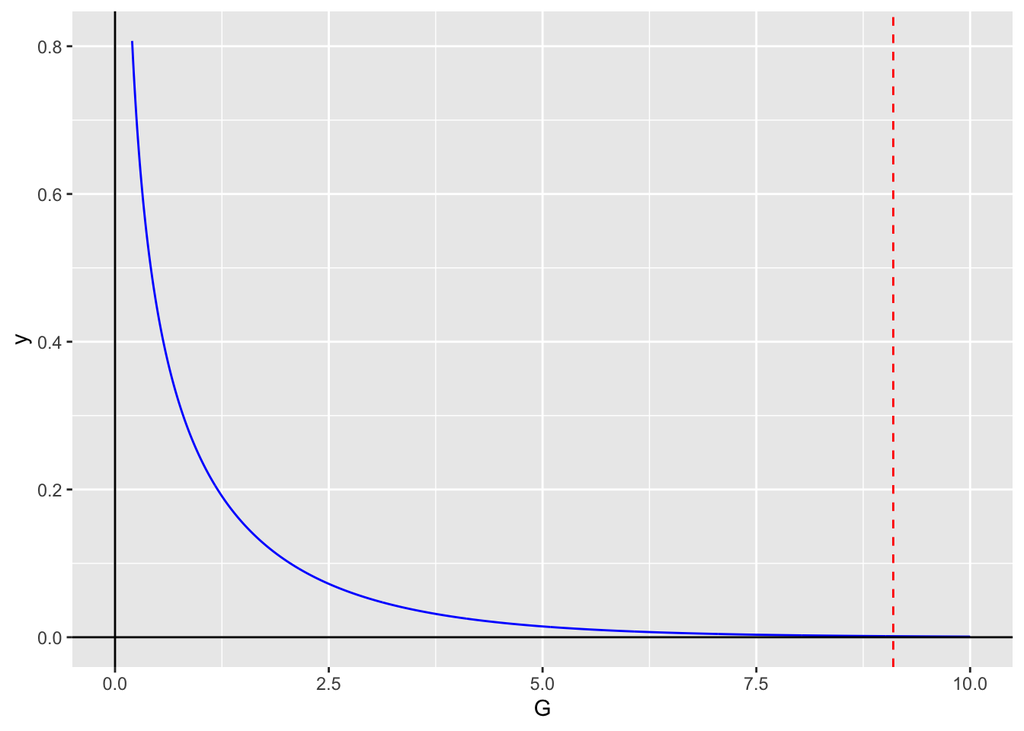

```r
ggplot() +
  geom_chisq_fill(df = 1, a = extra_sum$G, b = 10) +
  geom_chisq_density(df = 1, a = 0.2, b = 10) +
  geom_hline(yintercept = 0) +
  geom_vline(xintercept = extra_sum$G, linetype = "dashed", color = "red") +
  geom_vline(xintercept = 0) +
  xlab("G")
```

- The p-value from the likelihood ratio test is the area to the right of $G = 9.10$ under a chi-square random variable with one degree of freedom which is about 0.0026.

### 4

> Write three criticisms of the assumptions made for the previous three hypothesis tests where reality may differ from the assumptions, possibly leading to misleading conclusions.

Here are several possible responses:

- There are only seven chimpanzees in the experiment and all live in the same social group. These chimpanzees may not be representative of all chimpanzees, including those in other research stations or in the wild.
- Trials within the same session may not be independent.
- Different chimpanzees may exhibit different behavior in the long run.
- The probability of making the prosocial choice might differ over time within sessions.
- The probability of making the prosocial choice might differ between sessions.